# Rmarkdown写作

林炳清(2020000000)

2020/3/4

## R 语言

在**统计计算与软件**这门课程中，我们将系统的学习R语言，包括：

1. R的数据结构
   - 向量
   - 矩阵
   - 列表
   - 数据框
2. R语言编程结构
3. 统计计算与模拟
4. 输入和输出
5. 画图
6. 调试
7. 性能提升
   - 内存管理
   - 并行运算

R语言是世界上**最好**的数据分析软件之一，在*学术*和*商业领域*都有广泛的应用。我们还将使用Rstudio的Rmarkdown编辑数据分析报告。在Rmarkdown中，我们可以添加代码，并且得到代码的运行结果：

```r
a = 2
b = 10
a^b
```

```
## [1] 1024
```

在Rmarkdown中，我们还能直接得到可视化结果，例如：

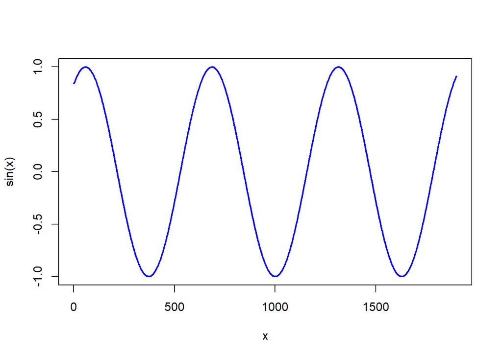

```r
plot(sin(seq(1,20,0.01)), type="l", lwd=2, xlab = "x", ylab="sin(x)", col="blue")
```

## 计算与模拟

在**统计计算与软件**这门课中，我们还将学习使用R做计算与模拟。比如，我们可能会使用R计算古典概率。

假设有$n$个独立事件，其中第$i$个事件的发生概率为$P_i$。求恰好有一个事件发生的概率。

首先假设$n=3$，事件记作A,B,C；那么P(有一件事情发生)为P(A发生而BC没有发生)，P(B发生而AC没有发生)，P(C发生而AB没有发生)的和。很明显P(A发生而BC没有发生)=$P_A(1-P_B)(1-P_c)$，以次类推，对于一般情形，我们有
$$\sum_{i=1}^n p_i(1-p_1)\ldots(1-p_{i-1})(1-p_{i+1})\ldots(1-p_{n}).$$

## 总结

在**统计计算与软件**这门课中，我们将系统学习R，并且学习使用R做计算与模拟。